# IE2152 Statistics for IE Project Final Project

### 3.1.2. Frequency Distribution

Frequency distribution is computed via using intervals which has equal widths according to range of data. Cumulative and relative frequencies are calculated below for all samples. A Frequency Distribution shows us that the summary data grouping is mutually divided into special classes and the number that occurs in a class. It is a way of expressing disorganized data. In this way, all categories in data 22 are specified with their classes. …

```r
#Frequency Distribution for all samples
n2<-nrow(data_22)
  k<-ceiling(log(n2,base=2))

  for(i in 1:5){
  if(i==1) {x=data_22$CE
            lab="Current Expenditures"}
  if(i==2) {x=data_22$PE
            lab="Personnel Expenditures"}
  if(i==3) {x=data_22$OCE
            lab="Other Current Expenditures"}
  if(i==4) {x=data_22$D
            lab="Defence"}
  if(i==5) {x=data_22$GNP
            lab="GNP"}


  w<-round(diff(range(x))/k,1)
  breaks<- seq(w*floor(min(x)/w),w*ceiling(max(x)/w),w)
  x.cut <- cut(x, breaks,right=F)
  x.freq <- table(x.cut)
  x.relfreq <- x.freq / length(x)
  x.cumfreq <- cumsum(x.freq)
  x.cumrelfreq <- x.cumfreq / length(x)
  print(paste("Frequency table for",lab))
  print(cbind(x.freq, x.relfreq, x.cumfreq,x.cumrelfreq))
  cat("\n")

  }
```

```
## [1] "Frequency table for Current Expenditures"
##                     x.freq x.relfreq x.cumfreq x.cumrelfreq
## [0,3.9e+08)             27   0.64286        27       0.6429
## [3.9e+08,7.8e+08)        3   0.07143        30       0.7143
## [7.8e+08,1.17e+09)       5   0.11905        35       0.8333
## [1.17e+09,1.56e+09)      3   0.07143        38       0.9048
## [1.56e+09,1.95e+09)      2   0.04762        40       0.9524
## [1.95e+09,2.34e+09)      1   0.02381        41       0.9762
## [2.34e+09,2.73e+09)      1   0.02381        42       1.0000
##
## [1] "Frequency table for Personnel Expenditures"
##                     x.freq x.relfreq x.cumfreq x.cumrelfreq
## [0,3.28e+08)            27   0.64286        27       0.6429
## [3.28e+08,6.55e+08)      3   0.07143        30       0.7143
## [6.55e+08,9.83e+08)      4   0.09524        34       0.8095
## [9.83e+08,1.31e+09)      4   0.09524        38       0.9048
## [1.31e+09,1.64e+09)      2   0.04762        40       0.9524
## [1.64e+09,1.97e+09)      1   0.02381        41       0.9762
## [1.97e+09,2.29e+09)      1   0.02381        42       1.0000
##
## [1] "Frequency table for Other Current Expenditures"
##                     x.freq x.relfreq x.cumfreq x.cumrelfreq
## [0,6.25e+07)            28   0.66667        28       0.6667
## [6.25e+07,1.25e+08)      2   0.04762        30       0.7143
## [1.25e+08,1.88e+08)      5   0.11905        35       0.8333
## [1.88e+08,2.5e+08)       4   0.09524        39       0.9286
## [2.5e+08,3.13e+08)       2   0.04762        41       0.9762
## [3.13e+08,3.75e+08)      0   0.00000        41       0.9762
## [3.75e+08,4.38e+08)      1   0.02381        42       1.0000
##
## [1] "Frequency table for Defence"
##                     x.freq x.relfreq x.cumfreq x.cumrelfreq
## [0,5.09e+07)            25   0.59524        25       0.5952
## [5.09e+07,1.02e+08)      4   0.09524        29       0.6905
## [1.02e+08,1.53e+08)      3   0.07143        32       0.7619
## [1.53e+08,2.03e+08)      6   0.14286        38       0.9048
## [2.03e+08,2.54e+08)      3   0.07143        41       0.9762
## [2.54e+08,3.05e+08)      0   0.00000        41       0.9762
## [3.05e+08,3.56e+08)      1   0.02381        42       1.0000
##
## [1] "Frequency table for GNP"
##                     x.freq x.relfreq x.cumfreq x.cumrelfreq
## [0,3.06e+09)            28   0.66667        28       0.6667
## [3.06e+09,6.11e+09)      6   0.14286        34       0.8095
## [6.11e+09,9.17e+09)      4   0.09524        38       0.9048
## [9.17e+09,1.22e+10)      2   0.04762        40       0.9524
## [1.22e+10,1.53e+10)      1   0.02381        41       0.9762
## [1.53e+10,1.83e+10)      0   0.00000        41       0.9762
## [1.83e+10,2.14e+10)      1   0.02381        42       1.0000
```

…

### 3.1.3. Descriptive Plots

Budget Expenditure data set such as Current Expenditure, Personnel Expenditure etc. is a continuous data type because of price is uncountable. Steam and leaf, dot plot, frequency graph, histogram, time-series plot were used for the data set to visualize the subdata one by one. …

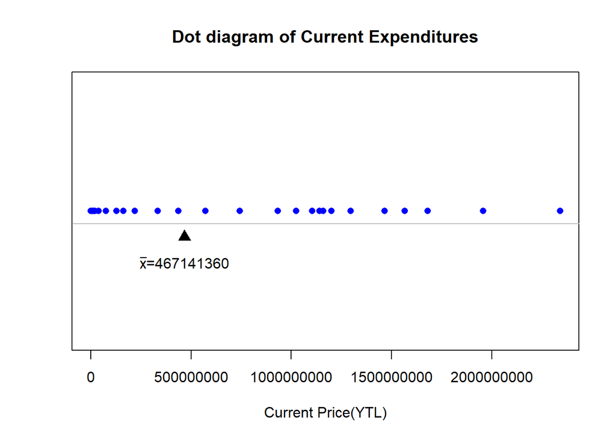

```
## [1] "Stem and leaf diagram of Current Expenditures"
##
##   The decimal point is 8 digit(s) to the right of the |
##
##    0 | 0000000000000000001124836
##    2 | 23
##    4 | 47
##    6 | 4
##    8 | 3
##   10 | 2046
##   12 | 00
##   14 | 77
##   16 | 8
##   18 | 6
##   20 |
##   22 | 4
```

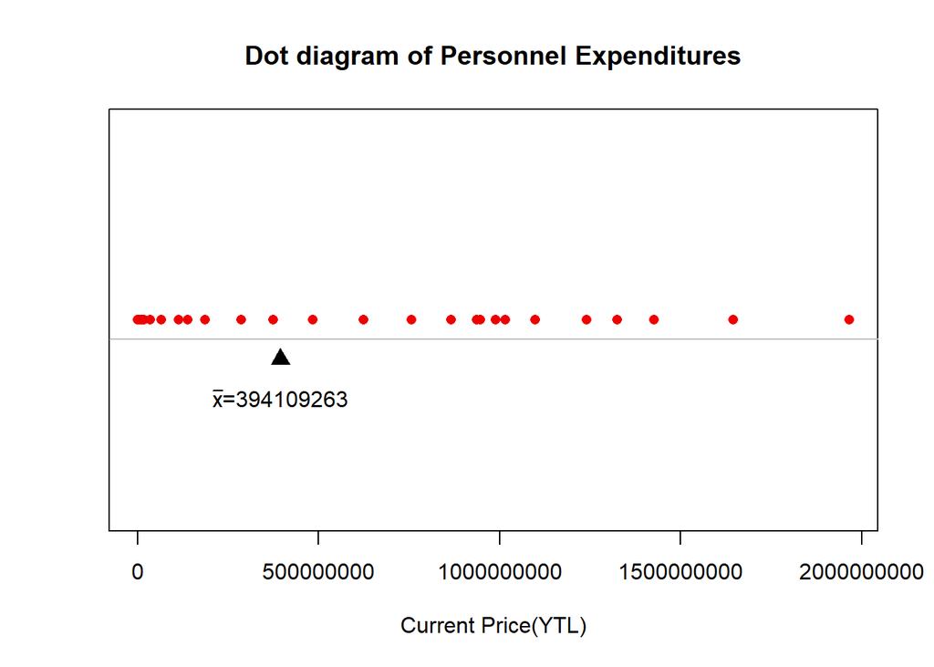

```
## [1] "Stem and leaf diagram of Personnel Expenditures"
##
##   The decimal point is 8 digit(s) to the right of the |
##
##    0 | 00000000000000000011237149
##    2 | 97
##    4 | 8
##    6 | 26
##    8 | 7459
##   10 | 20
##   12 | 42
##   14 | 3
##   16 | 5
##   18 | 7
```

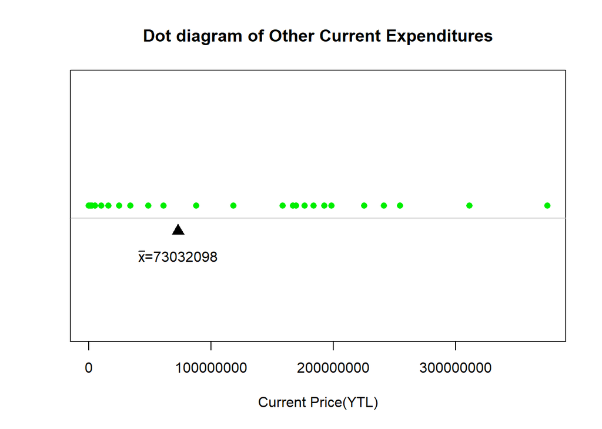

```
## [1] "Stem and leaf diagram of Other Current Expenditures"
##
##   The decimal point is 8 digit(s) to the right of the |
##
##   0 | 00000000000000000000011223
##   0 | 569
##   1 | 2
##   1 | 677889
##   2 | 034
##   2 | 5
##   3 | 1
##   3 | 8
```

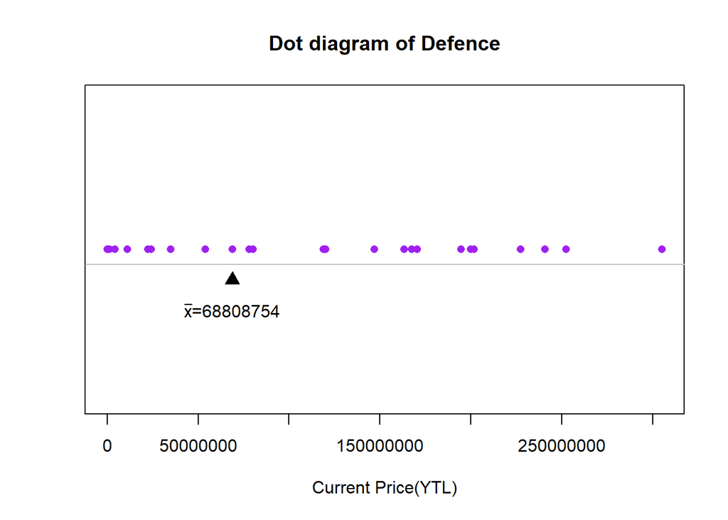

```
## [1] "Stem and leaf diagram of Defence"
##
##   The decimal point is 8 digit(s) to the right of the |
##
##   0 | 0000000000000000000001223
##   0 | 5788
##   1 | 22
##   1 | 56779
##   2 | 0034
##   2 | 5
##   3 | 1
```

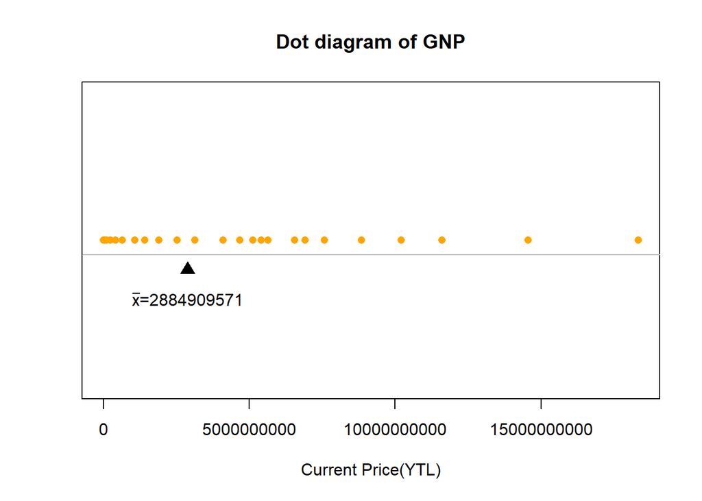

```
## [1] "Stem and leaf diagram of GNP"
##
##   The decimal point is 9 digit(s) to the right of the |
##
##    0 | 000000000000000000011247149
##    2 | 51
##    4 | 17146
##    6 | 696
##    8 | 8
##   10 | 26
##   12 |
##   14 | 6
##   16 |
##   18 | 3
```

```r
#Descriptive Plots
 col=c('blue','red2','green2','purple', 'orange')

 for(i in 1:5){
  if(i==1) {x=data_22$CE
            lab="Current Expenditures"}
  if(i==2) {x=data_22$PE
            lab="Personnel Expenditures"}
  if(i==3) {x=data_22$OCE
            lab="Other Current Expenditures"}
  if(i==4) {x=data_22$D
            lab="Defence"}
  if(i==5) {x=data_22$GNP
            lab="GNP"}

#Dot diagram
stripchart(x, xlab="Current Price(YTL)",
           main=paste("Dot diagram of",lab),
           method="stack",
           pch=16,
           col=col[i])

points(x=mean(x), y=0.8, pch=17, cex=1.5)

abline(h=0.9,col='gray')

text(x=mean(x), y=0.6, labels=bquote(bar(x)*"=" * .(mean(x))))

#Stem-and-leaf diagram
print(paste("Stem and leaf diagram of",lab))
stem(x)
 }
```

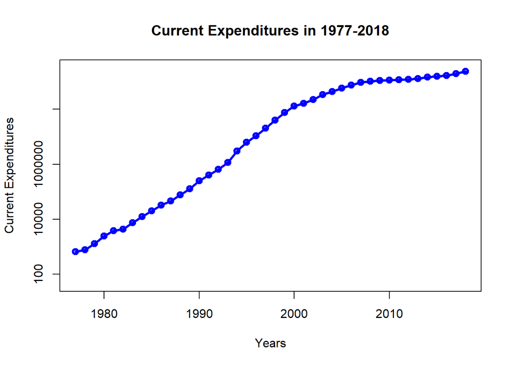

```r
#Time-Series was plotted.
plot(x=data_22$BE,
     y=data_22$CE,
     xlim=c(1977, 2018),  ## with c()
     ylim=c(50, 3000000000),  ## with c()
     log="y", col="blue",xlab = "Years", ylab = "Current Expenditures", main = "Current Expenditures in 1977-2018", type = "o", lwd="3")
```

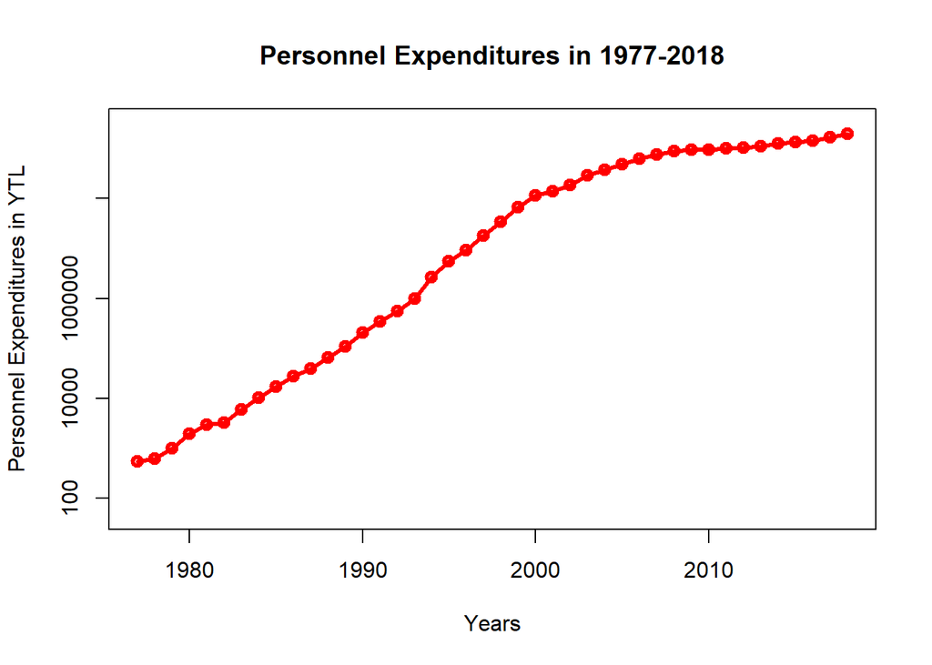

```r
plot(x=data_22$BE,
     y=data_22$PE,
     xlim=c(1977, 2018),  ## with c()
     ylim=c(50, 3000000000),  ## with c()
     log="y", col="red",xlab = "Years", ylab = "Personnel Expenditures in YTL", main = "Personnel Expenditures in 1977-2018", type = "o", lwd="3")
```

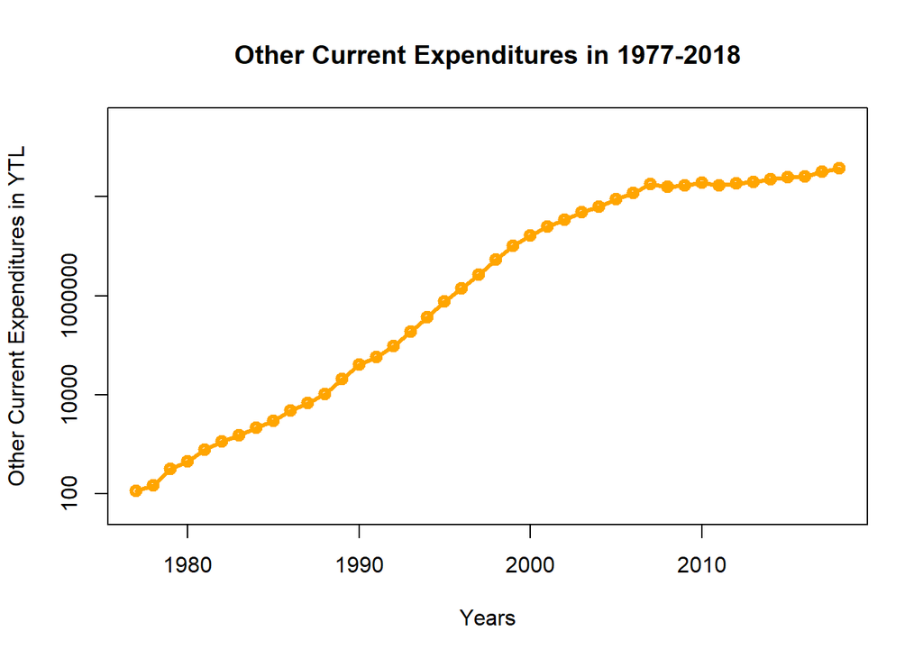

```r
plot(x=data_22$BE,
     y=data_22$OCE,
     xlim=c(1977, 2018),  ## with c()
     ylim=c(50, 3000000000),  ## with c()
     log="y", col="orange",xlab = "Years", ylab = "Other Current Expenditures in YTL", main = "Other Current Expenditures in 1977-2018", type = "o", lwd="3")
```

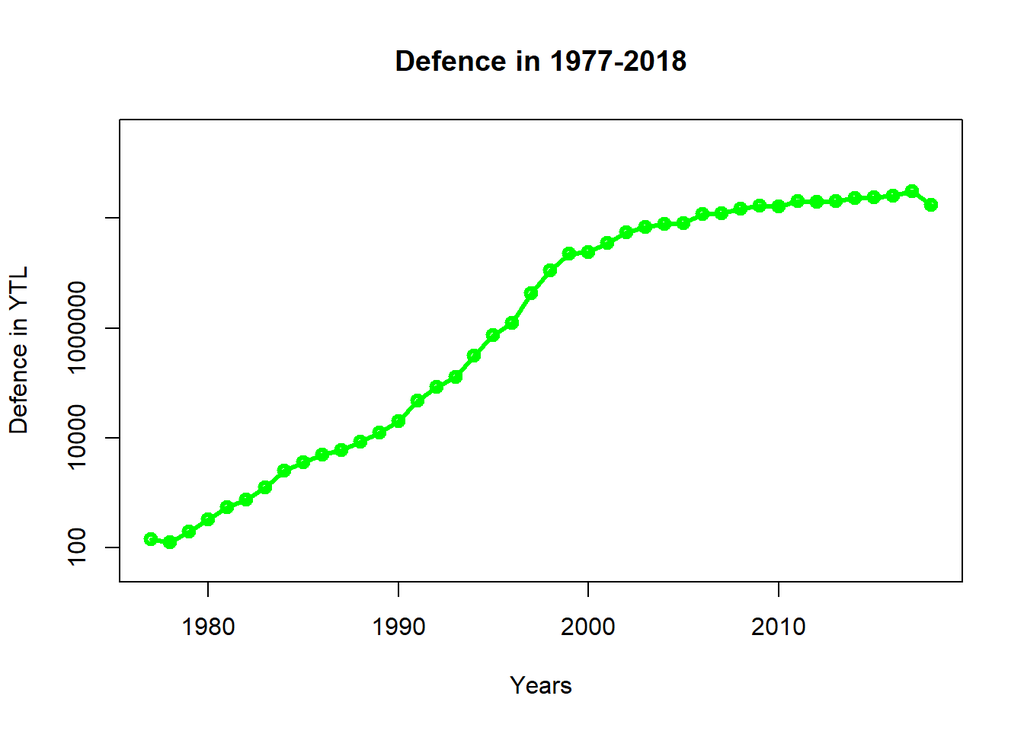

```r
plot(x=data_22$BE,
     y=data_22$D,
     xlim=c(1977, 2018),  ## with c()
     ylim=c(50, 3000000000),  ## with c()
     log="y", col="green",xlab = "Years", ylab = "Defence in YTL", main = "Defence in 1977-2018", type = "o", lwd="3")
```

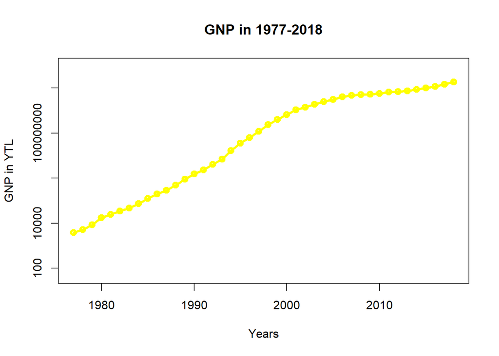

```r
plot(x=data_22$BE,
     y=data_22$GNP,
     xlim=c(1977, 2018),  ## with c()
     ylim=c(50, 90000000000),  ## with c()
     log="y", col="yellow",xlab = "Years", ylab = "GNP in YTL", main = "GNP in 1977-2018", type = "o", lwd="3")
```

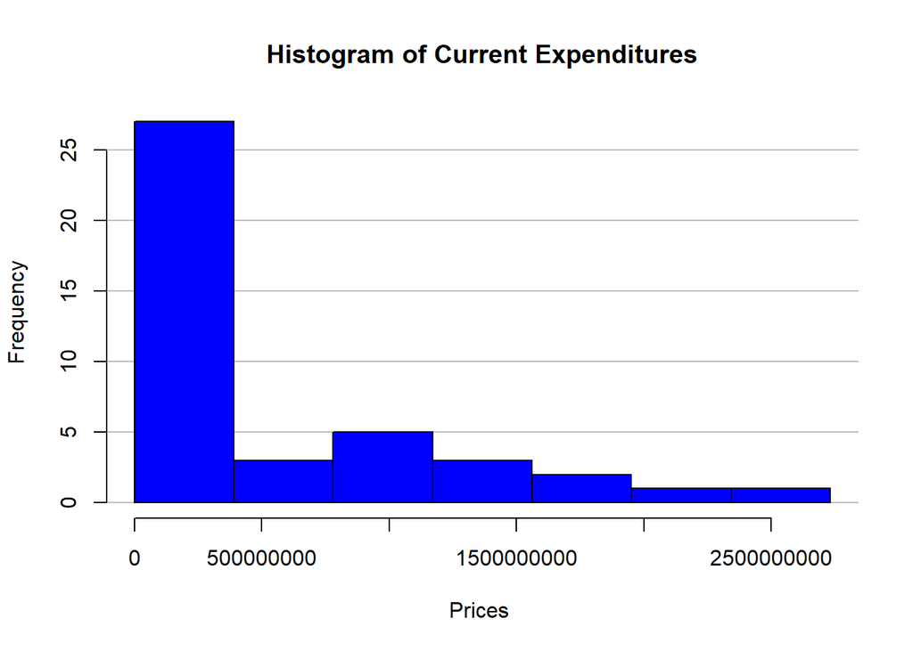

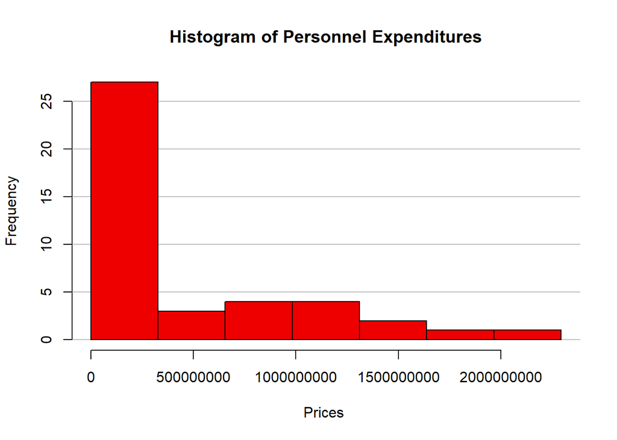

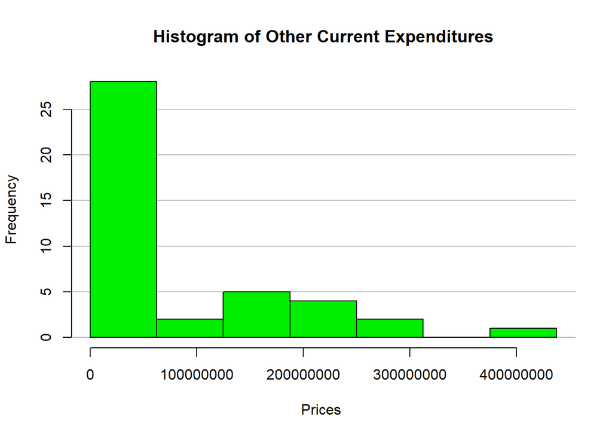

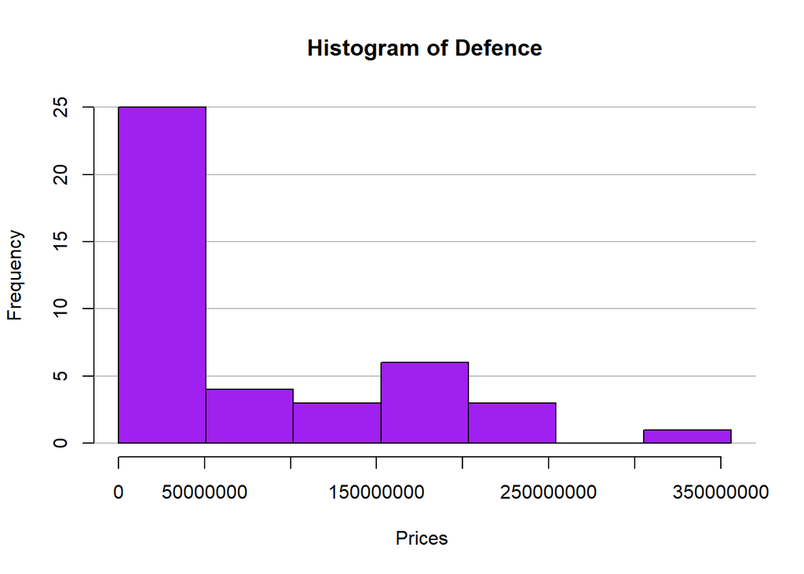

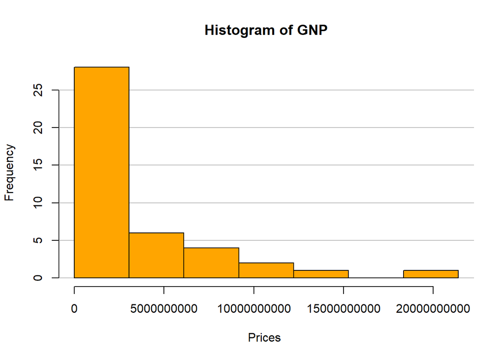

```r
#Histogram

for(i in 1:5){
  if(i==1) {x=data_22$CE
            lab="Current Expenditures"}
  if(i==2) {x=data_22$PE
            lab="Personnel Expenditures"}
  if(i==3) {x=data_22$OCE
            lab="Other Current Expenditures"}
  if(i==4) {x=data_22$D
            lab="Defence"}
  if(i==5) {x=data_22$GNP
            lab="GNP"}
  w<-round(diff(range(x))/k,1)
  breaks<- seq(w*floor(min(x)/w),w*ceiling(max(x)/w),w)

  hist(x,breaks,right=F,
       xlab="Prices ",
       main=paste("Histogram of",lab))

  abline(h=seq(0,60,5),col='gray')
  hist(x,breaks,col=col[i],add=T,right=F)
}
```

```r
#Box PlotS

BE_list <- (data_22$BE)
PE_list <- (data_22$PE)
CE_list <- (data_22$CE)
OCE_list <- (data_22$OCE)
D_list <- (data_22$D)
GNP_list <- (data_22$GNP)

"FOR CURRENT EXPENDITURES"
```

```
## [1] "FOR CURRENT EXPENDITURES"
```

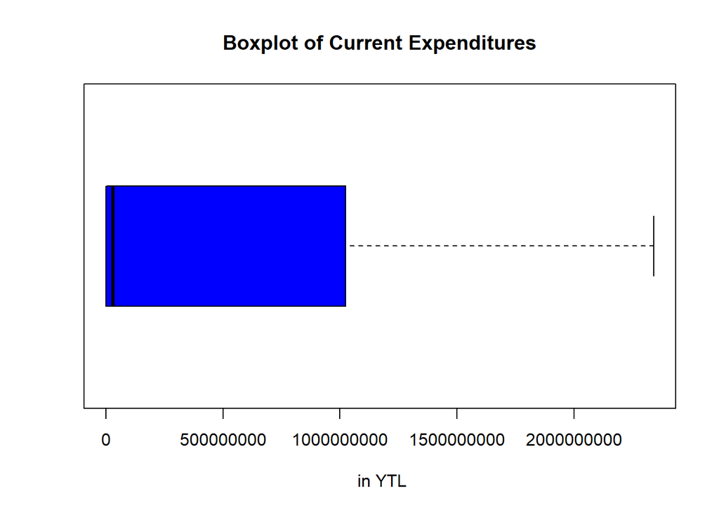

```r
boxplot(CE_list,main='Boxplot of Current Expenditures',pch="*",xlab=' in YTL',col='blue',horizontal=T)
```

```r
"FOR PERSONNEL EXPENDITURES"
```

```
## [1] "FOR PERSONNEL EXPENDITURES"
```

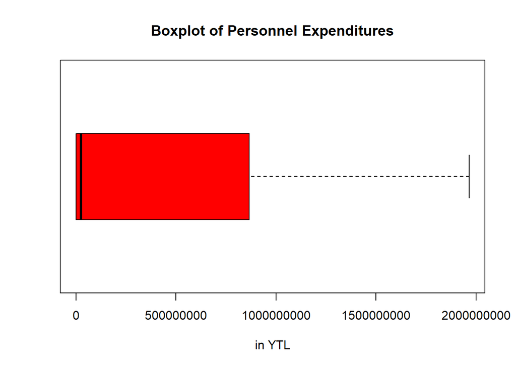

```r
boxplot(PE_list,main='Boxplot of Personnel Expenditures',pch="*",xlab='in YTL',col='red',horizontal=T)
```

```r
"FOR OTHER CURRENT EXPENDITURES"
```

```
## [1] "FOR OTHER CURRENT EXPENDITURES"
```

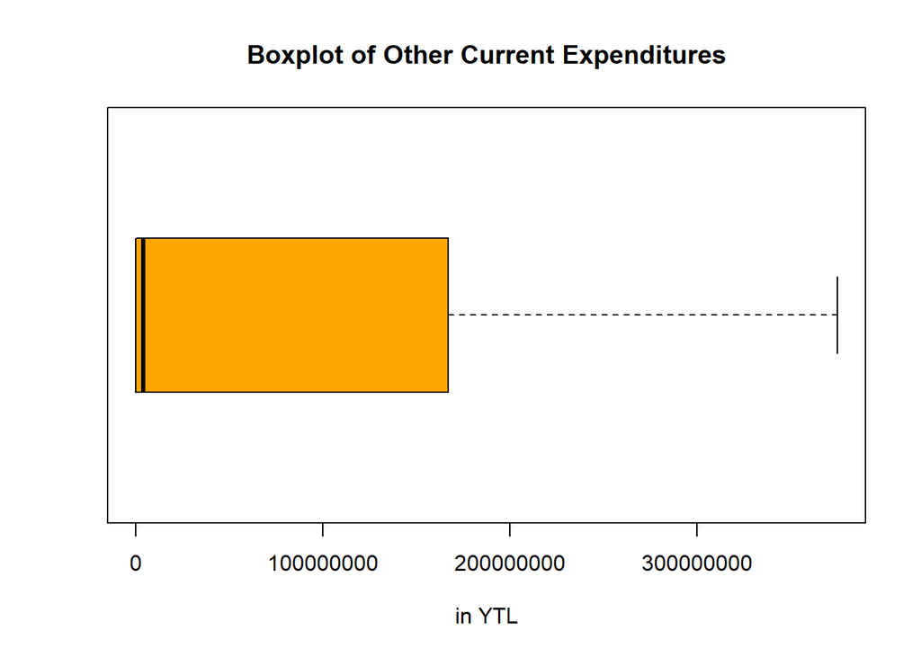

```r
boxplot(OCE_list,main='Boxplot of Other Current Expenditures',pch="*",xlab='in YTL',col='orange',horizontal=T)
```

```r
"FOR DEFENCE"
```

```
## [1] "FOR DEFENCE"
```

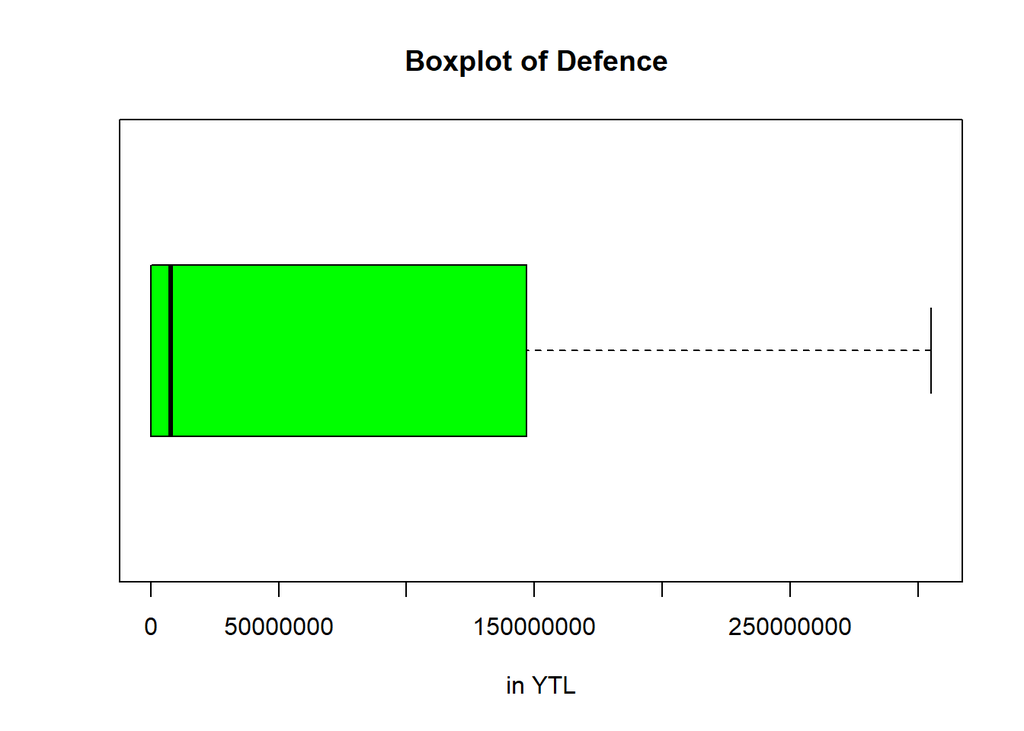

```r
boxplot(D_list,main='Boxplot of Defence ',pch="*",xlab='in YTL',col='green',horizontal=T)
```

```r
"FOR GNP"
```

```
## [1] "FOR GNP"
```

```r
boxplot(GNP_list,main='Boxplot of GNP',pch="*",xlab='in YTL',col='yellow',horizontal=T)
GNP.out<-boxplot.stats(GNP_list)$out; GNP.out
```

```
## [1] 14551761179 18334799699
```

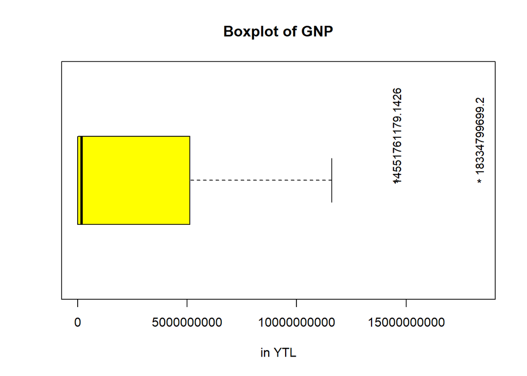

```r
text(cex=0.9,y=1.2,x=GNP.out,labels=as.list(GNP.out),srt=90)
```

…